### Pontifícia Universidade Católica de São Paulo (PUC-SP)

# Treinando Preditores Lineares e Logísticos

### Bacharelado em Ciência de Dados e Inteligência Artificial

#### Turma: CDIA21-MA

**Aluno:** Lucas Lopes Amorim

**Professor:** Jefferson de Oliveira Silva

# ESSE CADERNO AINDA ESTÁ EM CONSTRUÇÃO

**Dúvidas:**

Scaling muda a correlação?

A correlação de Pearson funciona para features binárias? Posso confiar?

Devo experimentar feature engineering com todas as variáveis ou só as que tem correlação alta?

Fit do scalling por coluna ou por dataset?

Regressão linear pode ser feita para prever variável não-contínua?

A maioria dos modelos lineares se beneficia da padronização dos dados. Por que frequentemente padronizar é melhor que normalizar?

Como lidar com outliers? Posso simplesmente remove-los?

#### Próximos Passos:

- [x] explorar os feature selectors do sklearn
- [ ] explorar mais os dados com dataviz
- [x] reduzir o número de classes do output
- [ ] regressão linear
- [ ] trazer nps para a análise exploratória
- [ ] reduzir código repetido

**Estrutura:**

1. Análise Exploratória\ 1.1. Classificando variáveis\ 1.2, Simplificando classes
2. Predizendo a motivação dos alunos\ 2.1. Selecionando Features com o auxílio do scikit-learn\ 2.2. Regressão Logística multiclasse (1 feature)\ 2.3. Regressão Logística multiclasse (3 features)\ 2.4. Regressão Logística multiclasse simplificada
3. Predizendo renda dos alunos\ 3.1. Selecionando Features com o auxílio do scikit-learn\ 3.2. Regressão Linear (1 feature)\ 3.3. Regressão Linear multi-feature

# 1. Análise Exploratória

Voltar ao topo

```python
import pandas as pd
import numpy as np
import random
from cdia.datasets import DatasetEstudantes
from sklearn.model_selection import train_test_split
%matplotlib inline
import matplotlib.pyplot as plt
import seaborn as sns
import warnings
warnings.simplefilter('ignore')
sns.set(font_scale=2)
pd.plotting.register_matplotlib_converters()
```

```python
n_amostra = 10000

random.seed(42)
#  O método criar retorna um DataFrame (Pandas)
df = DatasetEstudantes.criar(n_amostra)
```

```python
df.head()
```

|  | matrícula | nome | idade | renda | cor | sexo | ano_curso | escola | cod_curso | logradouro | numero | bairro | cidade | uf | cep | motivação |
| --- | --- | --- | --- | --- | --- | --- | --- | --- | --- | --- | --- | --- | --- | --- | --- | --- |
| 0 | RA55000001 | Maceane Arantes | 19 | 268.00 | 1 | 2 | 3 | 1 | 24 | Rua Emílio Barbosa | 875 | Vila Prudente | São Paulo | SP | 03135-040 | 10 |
| 1 | RA55000002 | Ecilo Abranches | 19 | 487.99 | 1 | 1 | 3 | 1 | 8 | Rua Major Walter Carlson | 532 | Jardim Arpoador | São Paulo | SP | 05565-210 | 9 |
| 2 | RA55000003 | Wellington Colaço Gomide | 19 | 101.00 | 1 | 1 | 3 | 1 | 50 | Rua Major Almeida Queiroz | 127 | Instituto de Previdência | São Paulo | SP | 05531-020 | 10 |
| 3 | RA55000004 | Kazuhiko Frajuca Batata Galvão | 19 | 144.00 | 1 | 1 | 3 | 1 | 7 | Rua Capitão Prudente | 202 | Pinheiros | São Paulo | SP | 05422-050 | 10 |
| 4 | RA55000005 | Teixeira Mirandela Caeira | 19 | 43.00 | 1 | 1 | 3 | 1 | 48 | Rua João Gomes | 306 | Jardim Herculano | São Paulo | SP | 04920-040 | 10 |

```python
df.info()
```

```
<class 'pandas.core.frame.DataFrame'>
RangeIndex: 10000 entries, 0 to 9999
Data columns (total 16 columns):
 #   Column      Non-Null Count  Dtype
---  ------      --------------  -----
 0   matrícula   10000 non-null  object
 1   nome        10000 non-null  object
 2   idade       10000 non-null  int64
 3   renda       10000 non-null  float64
 4   cor         10000 non-null  int64
 5   sexo        10000 non-null  int64
 6   ano_curso   10000 non-null  int64
 7   escola      10000 non-null  int64
 8   cod_curso   10000 non-null  int64
 9   logradouro  10000 non-null  object
 10  numero      10000 non-null  object
 11  bairro      10000 non-null  object
 12  cidade      10000 non-null  object
 13  uf          10000 non-null  object
 14  cep         10000 non-null  object
 15  motivação   10000 non-null  int32
dtypes: float64(1), int32(1), int64(6), object(8)
memory usage: 1.2+ MB
```

```python
df.describe()
```

|  | idade | renda | cor | sexo | ano_curso | escola | cod_curso | motivação |
| --- | --- | --- | --- | --- | --- | --- | --- | --- |
| count | 10000.000000 | 10000.000000 | 10000.000000 | 10000.000000 | 10000.000000 | 10000.000000 | 10000.00000 | 10000.000000 |
| mean | 21.462400 | 5357.528002 | 1.140000 | 1.500000 | 3.616800 | 1.496900 | 56.43970 | 5.945400 |
| std | 5.063354 | 42653.373802 | 0.347004 | 0.500025 | 0.967084 | 0.500015 | 32.45347 | 3.169357 |
| min | 19.000000 | 0.000000 | 1.000000 | 1.000000 | 1.000000 | 1.000000 | 1.00000 | 0.000000 |
| 25% | 19.000000 | 1185.740000 | 1.000000 | 1.000000 | 3.000000 | 1.000000 | 28.00000 | 3.000000 |
| 50% | 20.000000 | 1865.430000 | 1.000000 | 1.500000 | 4.000000 | 1.000000 | 56.00000 | 6.000000 |
| 75% | 21.000000 | 2851.947500 | 1.000000 | 2.000000 | 4.000000 | 2.000000 | 85.00000 | 9.000000 |
| max | 50.000000 | 988657.000000 | 2.000000 | 2.000000 | 5.000000 | 2.000000 | 112.00000 | 10.000000 |

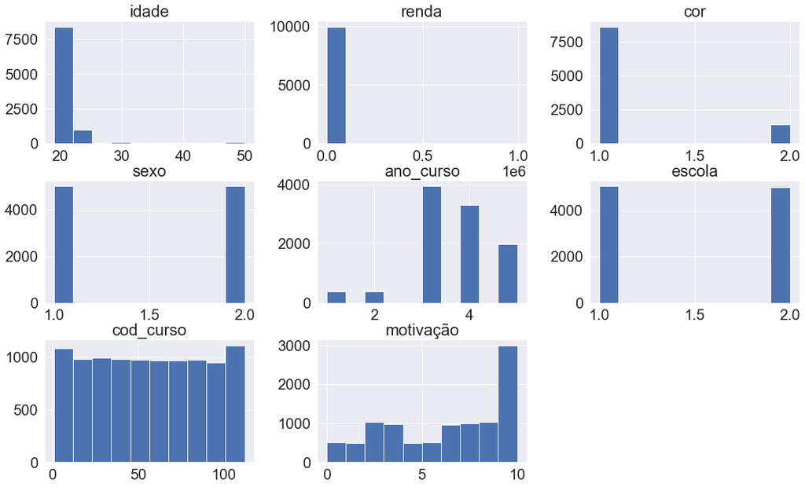

```python
plt.figure()
df.hist(figsize=(20,12))
plt.show()
```

## 1.1. Classificando Variáveis

[figure not shown]

Vamos agora classificar as nossas features(ou colunas) para entender melhorar como conduzir nossa análise exploratória.

| feature |  |  |
| --- | --- | --- |
| idade | Quantitativa | Discreta |
| renda | Quantitativa | Contínua |
| cor | Qualitativa | Nominal |
| sexo | Qualitativa | Nominal |
| ano_curso | Qualitativa | Ordinal |
| escola | Qualitativa | Nominal |
| motivação | Qualitativa | Ordinal |